# Лабораторная работа № 1

Установка и конфигурация операционной системы на виртуальную машину

Мальянц Виктория Кареновна

1132246740@rudn.ru

Российский университет дружбы народов

2026-15-02

# Цель работы

- Целью данной работы является приобретение практических навыков установки операционной системы на виртуальную машину, настройки минимально необходимых для дальнейшей работы сервисов.

# Задание

- Установка Rocky
- Выполнение домашнего задания

# Выполнение лабораторной работы

## Установка Rocky

- Скачала образ диска (рис. 1).

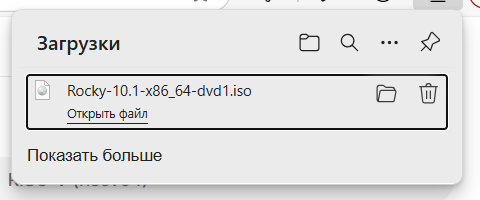

Образ диска

## Установка Rocky

- Начала создавать новую виртуальную машину, назвала ее vkmaljyanc и добавила образ диска (рис.2).

[figure not shown]

Настройка виртуальной машины

## Установка Rocky

- Продолжила настройку виртуальной машины (рис. 3).

[figure not shown]

Настройка виртуальной машины

## Установка Rocky

- Установила основную память на 2048 МБ (рис. 4).

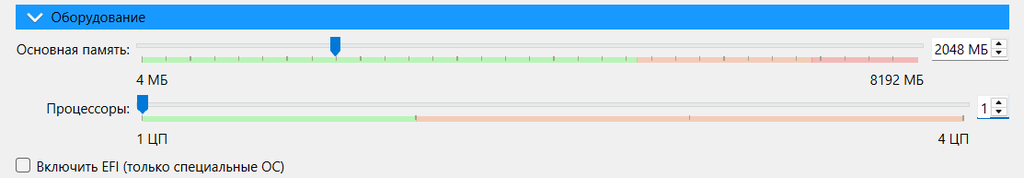

Установка памяти

## Установка Rocky

- Создала новый виртуальный жесткий диск (рис. 5).

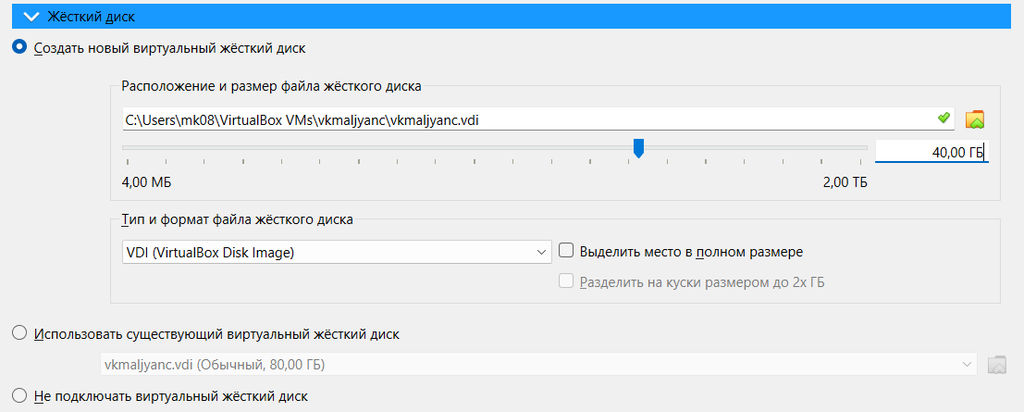

Создание нового виртуального жесткого диска

## Установка Rocky

- Выбрала язык (рис. 6).

[figure not shown]

Выбор языка

## Установка Rocky

- Перешла к установке Rocky Linux (рис. 7).

[figure not shown]

## Установка Rocky

- Настроила клавиатуру (рис. 8).

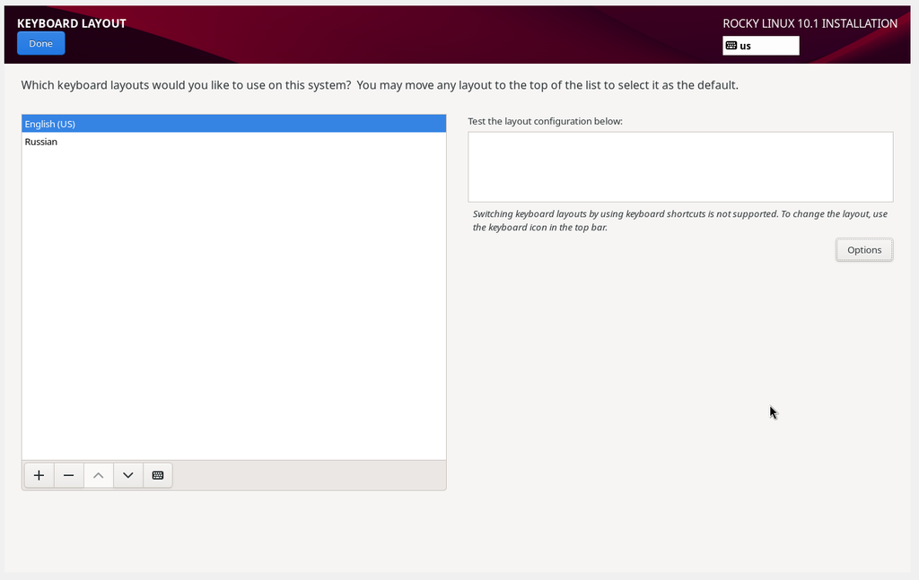

Настройка клавиатуры

## Установка Rocky

- Настроила часовой пояс (рис. 9).

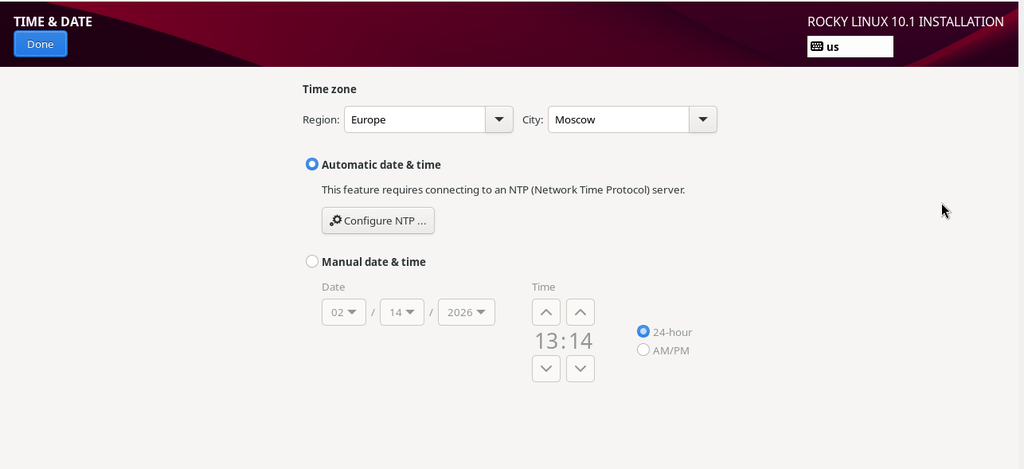

Настройка часового пояса

## Установка Rocky

- Выбрала параметры Server with GUI и Development Tools (рис. 10).

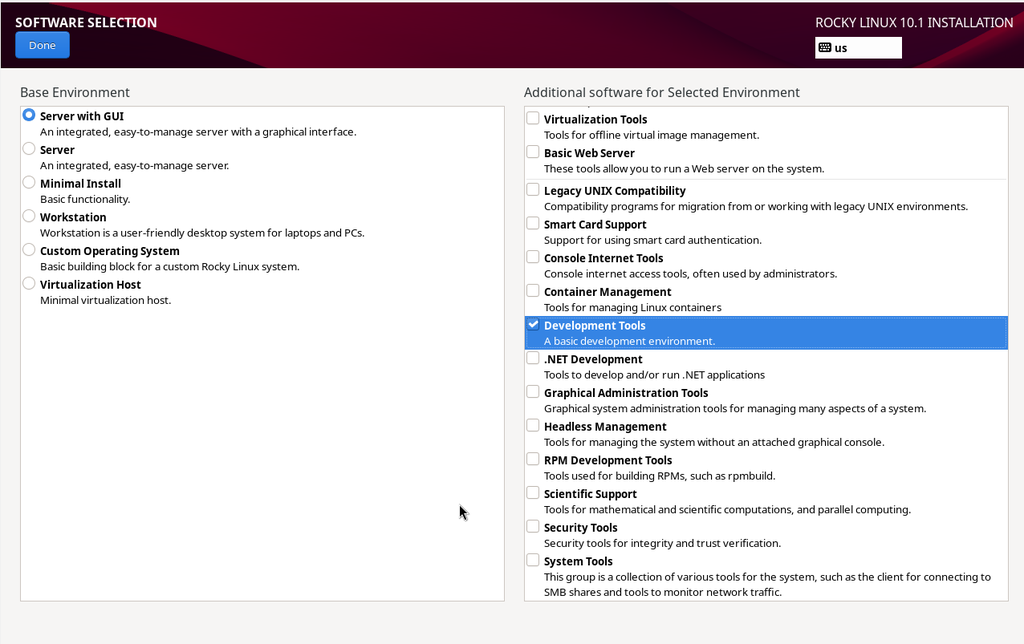

Выбор параметров Server with GUI и Development Tools

## Установка Rocky

- Отключила kdump (рис. 11).

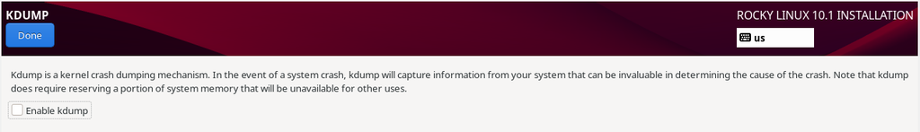

Отключение kdump

## Установка Rocky

- Создала пользователя (рис. 12).

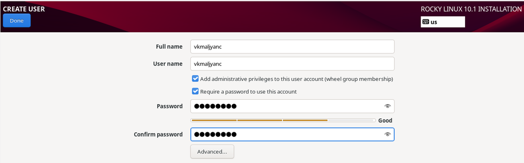

Создание пользователя

## Установка Rocky

- Установка завершена, перезагружаю виртуальную машину (рис. 13).

[figure not shown]

Завершение установки, перезагрузка виртуальной машины

## Установка Rocky

- Вхожу в аккаунт (рис. 14).

[figure not shown]

Вход в аккаунт

## Установка Rocky

- Задаю имя хоста (рис. 15).

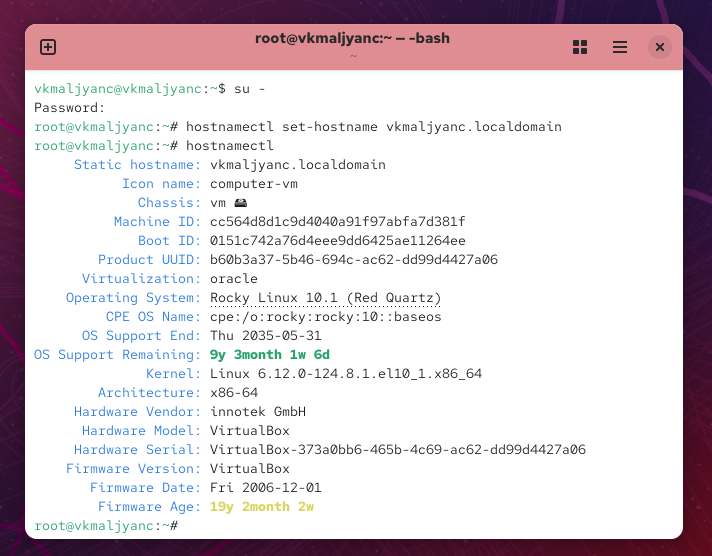

Создание имени для хоста

## Установка Rocky

- Добавила VBoxGuestAdditions.iso (рис. 16).

[figure not shown]

Добавление VBoxGuestAdditions.iso

## Выполнение домашнего задания

- Выполняю команду dmesg (рис. 17).

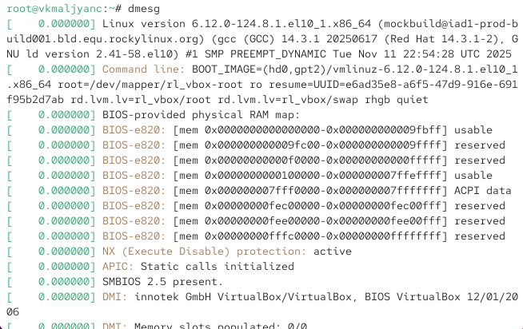

Выполнение команды dmesg

## Выполнение домашнего задания

- Получаю информацию о версии ядра Linux (рис. 19).

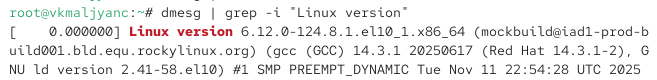

Получение информации о версии ядра Linux

## Выполнение домашнего задания

- Получаю информацию о частоте процессора (рис. 20).

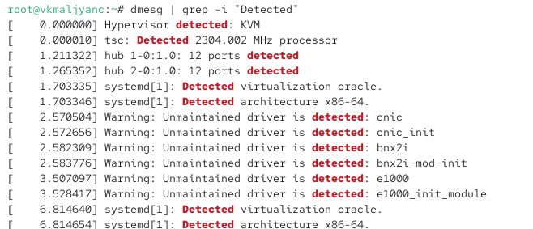

Получение информации о частоте процессора

## Выполнение домашнего задания

- Получаю информацию о модели процессора (рис. 21).

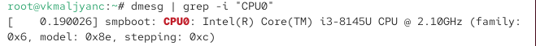

Получение информации о модели процессора

## Выполнение домашнего задания

- Получаю информацию об объеме доступной оперативной памяти (рис. 22).

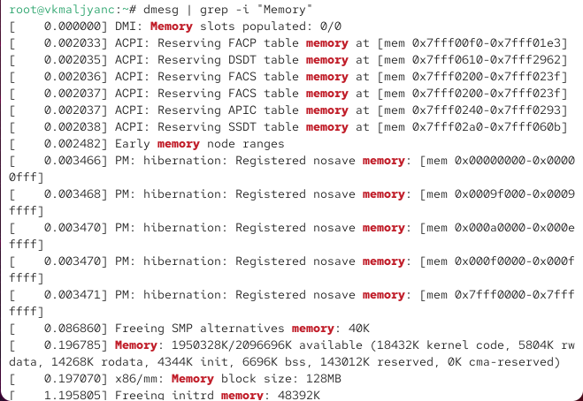

Получение информации об объеме доступной оперативной памяти

## Выполнение домашнего задания

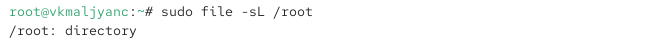

## Выполнение домашнего задания

- Получаю информацию о последовательности монтирования файловых систем (рис. 25).

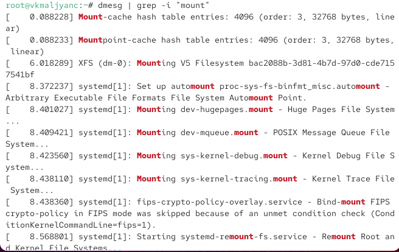

Получение информации о последовательности монтирования файловых систем

# Выводы

- Я приобрела практические навыки установки операционной системы на виртуальную машину, настройки минимально необходимых для дальнейшей работы сервисов.

# Спасибо за внимание